# Chapter 14.5 - Further adventures in covariance

```r
library(dagitty)
library(tidyverse)
library(brms)
library(tidybayes)
```

# Instrumental Variables

Just because there is correlation between education and wage does not mean anything causal. There are unobservables that influence both wage and level of education, such as IQ. Causality can still be teased out in this scenario through *instrumental variables*. An IV is a variable that exerts direct influence on education without directly influencing wages.

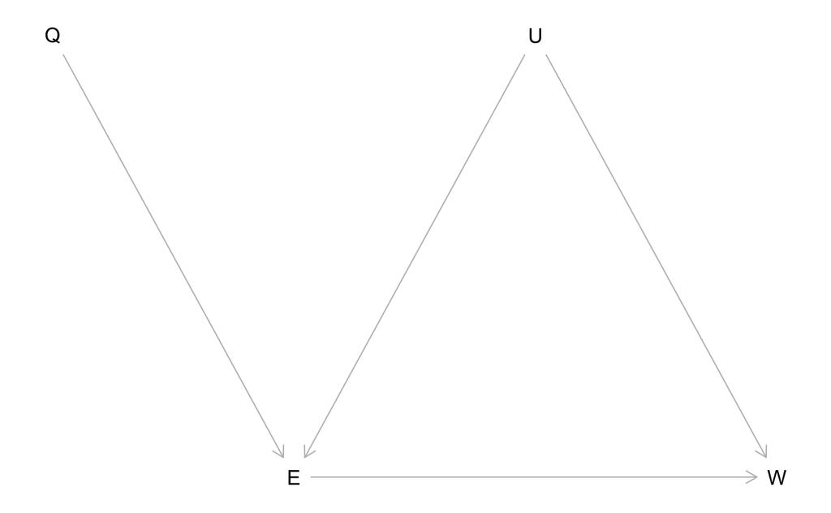

```r
dag_edu_wage <- dagitty('dag {
    Q [pos="0,-1.5"]
    E [pos="1,0"]
    U [pos="2,-1.5"]
    W [pos="3,0"]

    Q -> E
    E -> W
    E <- U -> W
}')
plot(dag_edu_wage)
```

In the wage/edu example, our instrumental variable of choice is birth time of year. Due to fixed semester dates, birth time of year induces variation in education without influencing wage (we would hope).

Lets simulate this data

```r
set.seed(73)
n <- 500
dat_sim <- tibble(
  U = rnorm(N),
  Q = sample(1:4 , size=N , replace=TRUE),
  E= rnorm(N , U + Q),
  # Assume .2
  W = rnorm(N , U + .2*E))

dat_sim %>%
  str
```

```
Classes ‘tbl_df’, ‘tbl’ and 'data.frame':   500 obs. of  4 variables:
 $ U: num  -0.145 0.2914 0.0938 -0.1274 -0.8468 ...
 $ Q: int  3 4 4 3 2 1 2 1 1 3 ...
 $ E: num  3.515 3.664 3.436 4.087 0.622 ...
 $ W: num  0.9194 1.5786 0.0234 0.0923 -1.1179 ...
```

$$
$$\begin{align}
\begin{pmatrix} wage_i \\ education_i \end{pmatrix} & \sim MVNormal(\begin{pmatrix} \mu_{wage,i} \\ \mu_{education,i} \end{pmatrix}, \textbf{S}) & \text{[Wage & Education co-vary]}
\\
\mu_{wage, i} & = \alpha_w + \beta_{education->wage}education_i
\\
\mu_{education,i} & = \alpha_{education} + \beta_{quarter->education}quarter_i
\\
\alpha_{wage}, \alpha_{education} &\sim Normal(0, .2)
\\
\beta_{education->wage}, \beta_{quarter->education} &\sim Normal(0, .5)
\\
\textbf{S} & \sim \begin{bmatrix} \sigma_{wage} & 0 \\ 0 & \sigma_{education} \end{bmatrix} \textbf{R} \begin{bmatrix} \sigma_{wage} & 0 \\ 0 & \sigma_{education} \end{bmatrix}
\\
\textbf{R} & \sim lkjCorr(2)
\end{align}$$
$$

```r
bform <-
  bf(W ~ 1 + E, family = gaussian) +
  bf(E ~ 1 + Q, family = gaussian)

b14.5 <- brm(bform,
             data = dat_sim,
             prior = c(prior(normal(0, .2), class = Intercept),
                       prior(normal(0, .5), class = b),
                       prior(exponential(1), class = "sigma", resp = E),
                       prior(exponential(1), class = "sigma", resp = W),
                       prior(lkj(2), class = rescor)),
    refresh = 0, sample_prior = "yes")
```

```
Setting 'rescor' to TRUE by default for this model
recompiling to avoid crashing R session
```

```r
summary(b14.5)
```

```
 Family: MV(gaussian, gaussian)
  Links: mu = identity; sigma = identity
         mu = identity; sigma = identity
Formula: W ~ 1 + E
         E ~ 1 + Q
   Data: dat_sim (Number of observations: 500)
Samples: 4 chains, each with iter = 2000; warmup = 1000; thin = 1;
         total post-warmup samples = 4000

Population-Level Effects:
            Estimate Est.Error l-95% CI u-95% CI Eff.Sample Rhat
W_Intercept    -0.11      0.15    -0.41     0.20       2354 1.00
E_Intercept    -0.26      0.15    -0.55     0.03       3004 1.00
W_E             0.16      0.06     0.03     0.28       1811 1.00
E_Q             0.99      0.05     0.89     1.10       3080 1.00

Family Specific Parameters:
        Estimate Est.Error l-95% CI u-95% CI Eff.Sample Rhat
sigma_W     1.57      0.07     1.45     1.72       1503 1.00
sigma_E     1.37      0.04     1.28     1.45       3261 1.00

Residual Correlations:
            Estimate Est.Error l-95% CI u-95% CI Eff.Sample Rhat
rescor(W,E)     0.55      0.05     0.45     0.64       1952 1.00

Samples were drawn using sampling(NUTS). For each parameter, Eff.Sample
is a crude measure of effective sample size, and Rhat is the potential
scale reduction factor on split chains (at convergence, Rhat = 1).
```

Now, we’ll compare the results to what would happen if we ignored the confounder

```r
b14.5.1 <- brm(W ~ 1 + E,
               data = d,
               prior = c(prior(normal(0, .2), class = Intercept),
                         prior(normal(0, .5), class = b)),
               refresh = 0)
summary(b14.5.1)
```

```
 Family: gaussian
  Links: mu = identity; sigma = identity
Formula: W ~ 1 + E
   Data: d (Number of observations: 500)
Samples: 4 chains, each with iter = 2000; warmup = 1000; thin = 1;
         total post-warmup samples = 4000

Population-Level Effects:
          Estimate Est.Error l-95% CI u-95% CI Eff.Sample Rhat
Intercept    -0.00      0.04    -0.08     0.08       4116 1.00
E             0.38      0.04     0.31     0.46       3647 1.00

Family Specific Parameters:
      Estimate Est.Error l-95% CI u-95% CI Eff.Sample Rhat
sigma     0.93      0.03     0.87     0.99       3562 1.00

Samples were drawn using sampling(NUTS). For each parameter, Eff.Sample
is a crude measure of effective sample size, and Rhat is the potential
scale reduction factor on split chains (at convergence, Rhat = 1).
```

# Continuous categories (Gaussian Process)